# Comparative Analysis (GardenSewa)

## 1. Introduction

This report analyzes a curated dataset of **93 garden and landscaping service listings** gathered from **25 companies** operating across **Kathmandu, Lalitpur, and Bhaktapur**. Each listing captures the service offered, the company name, the type of provider (organized company, individual/informal, or app/marketplace platform), contact details, location served, and the source links.

The goal of this analysis is to understand:

- Which garden services are most commonly offered in the market
- How the market is structured by provider type (formal vs. informal)
- How service availability is distributed geographically
- Which companies dominate the market in terms of service breadth

The following sections walk through the dataset, present six visualizations, and close with a consolidated set of key findings.

## 2. Setup

```python
# Importing the necessary libraries
import pandas as pd
import matplotlib.pyplot as plt
```

```python
# Loading the dataset
df_comp = pd.read_excel("Comparative_Analysis.xlsx")

print(df_comp.columns.tolist(), "\n")
print(df_comp.head())
```

```
['Service', 'Company Name', 'Type', 'Contact', 'Location', 'URL']

     Service               Company Name                    Type  \
0  Lawn Care    United Facility Service       Organized Company
1  Lawn Care       Champa's Garden Care  Individual or informal
2  Lawn Care  Multiple Facility Service       Organized Company
3  Lawn Care    Nepal Cleaning Solution       Organized Company
4  Lawn Care             Homework Nepal       Organized Company

                  Contact   Location  \
0  9851046561, 9851330803  Kathmandu
1              9841804266  Bhaktapur
2   9851098319, 015172116  Kathmandu
3           977 014610724  Kathmandu
4   9851227616, 014798604  Kathmandu

                                                 URL
0  https://unitedfacilityservice.com.np/professio...
1           https://champakhatiwada.com.np/#services
2  https://multiplefacilityservice.com/service/ga...
3  https://nepalcleaningsolution.com/services/gar...
4               https://homeworknepal.com/gardening/
```

## 3. Data Overview

```python
# Structural Summary
print(df_comp.info())
```

```
<class 'pandas.core.frame.DataFrame'>
RangeIndex: 93 entries, 0 to 92
Data columns (total 6 columns):
 #   Column        Non-Null Count  Dtype
---  ------        --------------  -----
 0   Service       93 non-null     object
 1   Company Name  93 non-null     object
 2   Type          93 non-null     object
 3   Contact       93 non-null     object
 4   Location      93 non-null     object
 5   URL           93 non-null     object
dtypes: object(6)
memory usage: 4.5+ KB
None
```

```python
# Statistical Summary
print(df_comp.describe())
```

```
                         Service   Company Name               Type  \
count                         93             93                 93
unique                        20             25                  3
top     Pest and Disease Control  Ajima Nursery  Organized Company
freq                          18             13                 83

           Contact   Location                                         URL
count           93         93                                          93
unique          26          3                                          35
top     9841224408  Kathmandu  https://www.ajimanursery.com/our-services/
freq            13         74                                          12
```

```python
# Frequency cont of each Service
print(df_comp["Service"].value_counts())
```

```
Service
Pest and Disease Control      18
Landscape Design              10
Garden Maintenance            10
Lawn Care                      9
Planting and Transplanting     7
Tree Pruning and Removal       6
Soil and Fertilizers           5
Hardscaping                    4
Flower Maintenance             4
Seasonal Services              3
Consultation Services          3
Irrigation Services            2
Tree Sales                     2
Landscape Lighting             2
Turfing Service                2
Temporary Gardening            2
Rooftop Gardening              1
Plant Propagation              1
Soil Improvement               1
Artificial Gardening           1
Name: count, dtype: int64
```

```python
# Frequency cont of each Provider Type
print(df_comp["Type"].value_counts())
```

```
Type
Organized Company              83
Individual or informal          5
App or marketplace platform     5
Name: count, dtype: int64
```

```python
# Frequency cont of each Location
print(df_comp["Location"].value_counts())
```

```
Location
Kathmandu    74
Lalitpur     14
Bhaktapur     5
Name: count, dtype: int64
```

**Insight:** The dataset spans **20 distinct services**, but coverage is highly uneven. The top service, Pest and Disease Control (18 listings), has almost 18x more listings than the four rarest services, Rooftop Gardening, Plant Propagation, Soil Improvement, Artificial Gardening, each with only 1. Provider Type is dominated by **Organized Company** (83), while **Individual or informal** and **App or marketplace platform** each account for just 5 listings, meaning the market is served mostly by formal businesses rather than freelancers or app based platforms. Location shows a similar pattern, with **Kathmandu** alone making up 74 of the 93 listings. **Lalitpur** (14) and **Bhaktapur** (5) trail far behind, suggesting that gardening and landscaping services are still concentrated in the capital and have not expanded much into nearby districts.

## 4. Visual Analysis

### Chart 1 - Number of Providers per Service

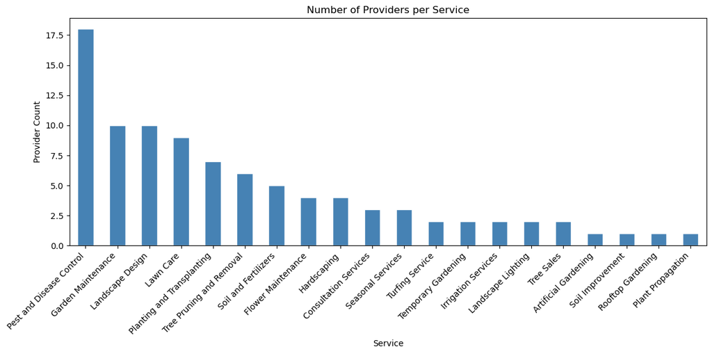

```python
provider_count = df_comp.groupby("Service")["Company Name"].count().sort_values(ascending=False)

plt.figure(figsize=(12,6))
provider_count.plot(kind="bar", color="steelblue", edgecolor="white")
plt.title("Number of Providers per Service")
plt.xlabel("Service")
plt.ylabel("Provider Count")
plt.xticks(rotation=45, ha="right")
plt.tight_layout()
plt.savefig("chart1.png", dpi=150, bbox_inches="tight")
plt.show()
```

**Insight:** Pest and Disease Control is by far the most saturated service, with 18 providers, followed by a tie between Garden Maintenance and Landscape Design, with 10 providers each, and Lawn Care, with 9. In contrast, Artificial Gardening, Soil Improvement, Rooftop Gardening, and Plant Propagation, have only a single provider each, indicating that these are niche or emerging offerings with room for new entrants.

### Chart 2 - Provider Type Distribution

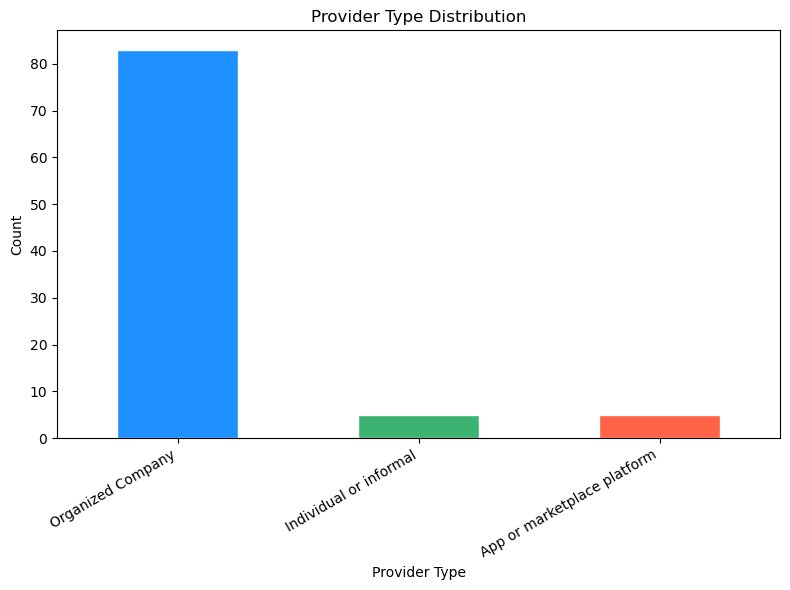

```python
plt.figure(figsize=(8,6))
df_comp["Type"].value_counts().plot(kind="bar", color=["dodgerblue", "mediumseagreen", "tomato"], edgecolor="white")
plt.title("Provider Type Distribution")
plt.xlabel("Provider Type")
plt.ylabel("Count")
plt.xticks(rotation=30, ha="right")
plt.tight_layout()
plt.savefig("chart2.png", dpi=150, bbox_inches="tight")
plt.show()
```

**Insight:** The garden services market is overwhelmingly formalized. Organized companies account for 83 of 93 listings. Individual or informal providers and app-based marketplace platforms are each a small minority, with 5 listings each. This suggests that the sector has consolidated around established businesses rather than gig-style or peer-to-peer providers.